# Exploratory Data Analysis - Titanic Dataset

**Brief Introduction:**

```
The 'Titanic' is a popular dataset for data analysis and machine learning. This dataset consists of information about the passengers onboard the 'Unsinkable' RMS Titanic, which was shiwrecked unfortuantely on April 15th, 1912, during her main voyage after colliding with an iceberg and thus resulted in the death of 1502 out of 2224 passengers and crew.
```

**Problem Statement:**

```
The dataset provided can be used to predict passengers survival rate out of the disaster. The features like age, gender, fare, cabin, survival_status, etc. are used to perform Exploratory Data Analysis (EDA) in this project.
```

**About the Data:**

```
      The dataset has the following features,
```

0. PassengerID: Unique ID of Passengers
1. Survived: Survival Status (Yes = 1, No = 0)
2. Pclass: Passenger Classes (1 = First Class, 2 = Second Class, 3 = Third Class)
3. Sex: Passengers Gender
4. Age: Passengers Age
5. SibSp: Number of Siblings/ or Spouses onboard,
6. Parch: Number of Parents/ Child onboard,
7. Fare: Fare paid for the ticket
8. Embarked: Part of embarkation (C = Cherbourg, Q = Queenstown, S = Southampton)
9. Name: Name of the Passengers
10. Cabin: Cabin Number
11. Ticket: Ticket Number

# Importing Libraries:

```python
import numpy as np
import pandas as pd
%matplotlib inline
from matplotlib import pyplot as plt
import seaborn as sns

import warnings
warnings.filterwarnings('ignore')

plt.style.use('fivethirtyeight')
sns.set_style('whitegrid')
```

# Loading the Dataset:

```python
df = pd.read_csv('Titanic-Dataset.csv')
```

# Exploring the Dataset:

**1. Exploring the dataset:**

```python
df.head(5)
```

|  | PassengerId | Survived | Pclass | Name | Sex | Age | SibSp | Parch | Ticket | Fare | Cabin | Embarked |
| --- | --- | --- | --- | --- | --- | --- | --- | --- | --- | --- | --- | --- |
| 0 | 1 | 0 | 3 | Braund, Mr. Owen Harris | male | 22.0 | 1 | 0 | A/5 21171 | 7.2500 | NaN | S |
| 1 | 2 | 1 | 1 | Cumings, Mrs. John Bradley (Florence Briggs Th... | female | 38.0 | 1 | 0 | PC 17599 | 71.2833 | C85 | C |
| 2 | 3 | 1 | 3 | Heikkinen, Miss. Laina | female | 26.0 | 0 | 0 | STON/O2. 3101282 | 7.9250 | NaN | S |
| 3 | 4 | 1 | 1 | Futrelle, Mrs. Jacques Heath (Lily May Peel) | female | 35.0 | 1 | 0 | 113803 | 53.1000 | C123 | S |
| 4 | 5 | 0 | 3 | Allen, Mr. William Henry | male | 35.0 | 0 | 0 | 373450 | 8.0500 | NaN | S |

```python
df.tail(5)
```

|  | PassengerId | Survived | Pclass | Name | Sex | Age | SibSp | Parch | Ticket | Fare | Cabin | Embarked |
| --- | --- | --- | --- | --- | --- | --- | --- | --- | --- | --- | --- | --- |
| 886 | 887 | 0 | 2 | Montvila, Rev. Juozas | male | 27.0 | 0 | 0 | 211536 | 13.00 | NaN | S |
| 887 | 888 | 1 | 1 | Graham, Miss. Margaret Edith | female | 19.0 | 0 | 0 | 112053 | 30.00 | B42 | S |
| 888 | 889 | 0 | 3 | Johnston, Miss. Catherine Helen "Carrie" | female | NaN | 1 | 2 | W./C. 6607 | 23.45 | NaN | S |
| 889 | 890 | 1 | 1 | Behr, Mr. Karl Howell | male | 26.0 | 0 | 0 | 111369 | 30.00 | C148 | C |
| 890 | 891 | 0 | 3 | Dooley, Mr. Patrick | male | 32.0 | 0 | 0 | 370376 | 7.75 | NaN | Q |

So, this is how are data looks like from the start and end.

**2. Checking the dimension of the dataset:**

```python
df.shape
```

```
(891, 12)
```

**Observation:**

1. We can see this dataset has 12 features available. We have previously described about these features.
2. We have, both, Numerical and Categorical data present in the Dataset.

**3. Fetching the info about the dataset:**

```python
df.info
```

[output not shown]

[output cut: 25 more lines]

```python
df.info()
```

```
<class 'pandas.core.frame.DataFrame'>
RangeIndex: 891 entries, 0 to 890
Data columns (total 12 columns):
 #   Column       Non-Null Count  Dtype
---  ------       --------------  -----
 0   PassengerId  891 non-null    int64
 1   Survived     891 non-null    int64
 2   Pclass       891 non-null    int64
 3   Name         891 non-null    object
 4   Sex          891 non-null    object
 5   Age          714 non-null    float64
 6   SibSp        891 non-null    int64
 7   Parch        891 non-null    int64
 8   Ticket       891 non-null    object
 9   Fare         891 non-null    float64
 10  Cabin        204 non-null    object
 11  Embarked     889 non-null    object
dtypes: float64(2), int64(5), object(5)
memory usage: 83.7+ KB
```

**Observations:**

1. The Shape of the dataset is (891, 12) which indicates our dataset has 891 number of rows (/records) and 12 columns (/features). Each of the rows shows information about a single passenger. So, totally we have a dataset of 891 passengers in this case.
2. From the output gained, we have columns consist of the name of each column, along with two extra information namely, Non-null Count, which indicates how many non-null values are there in the dataset, and Dtype, which represents what type of value that particular column has.

   ```
      [  i. int64 means int value,
        ii. float64 means float value,
       iii. object means string value.]
   ```

3. In the 'age' column we can see that out of 891 values, we have 714 non-null values which implies the fact that we have (891 - 714) = 177 Null values present in that particular column.
4. Similarly, in the 'Cabin' feature, out of 891 values, we have only 204 non-null vlaues which implies we have (891 - 204) = 687 Null values. But, this poses a challenge espcially because the Null values present in this particualar column is huge. Only 23% of the data is present [(204/891)*100 = 23% (approx, 22.89% to be exact)], while 77% of the data is missing [(687/891)*100 = 77% (approx, 77.10% to be exact)]. So, we need to drop this particular feature.
5. In the 'Embarked' Column, we see 889 Non-null values, which leaves us only 2 Null (/missing) values. This is a minor issue that can be dealt with easily.
6. Except for the 'Age', 'Embarked', and 'Cabin' feature, we do not have any null values in other columns.

```python
df.nunique()
```

```
PassengerId    891
Survived         2
Pclass           3
Name           891
Sex              2
Age             88
SibSp            7
Parch            7
Ticket         681
Fare           248
Cabin          147
Embarked         3
dtype: int64
```

**Observation:**

Self-explanatory.

**4. Getting the Summary Statistics:**

```python
a = round(df.describe().T, 4)
a
```

|  | count | mean | std | min | 25% | 50% | 75% | max |
| --- | --- | --- | --- | --- | --- | --- | --- | --- |
| PassengerId | 891.0 | 446.0000 | 257.3538 | 1.00 | 223.5000 | 446.0000 | 668.5 | 891.0000 |
| Survived | 891.0 | 0.3838 | 0.4866 | 0.00 | 0.0000 | 0.0000 | 1.0 | 1.0000 |
| Pclass | 891.0 | 2.3086 | 0.8361 | 1.00 | 2.0000 | 3.0000 | 3.0 | 3.0000 |
| Age | 714.0 | 29.6991 | 14.5265 | 0.42 | 20.1250 | 28.0000 | 38.0 | 80.0000 |
| SibSp | 891.0 | 0.5230 | 1.1027 | 0.00 | 0.0000 | 0.0000 | 1.0 | 8.0000 |
| Parch | 891.0 | 0.3816 | 0.8061 | 0.00 | 0.0000 | 0.0000 | 0.0 | 6.0000 |
| Fare | 891.0 | 32.2042 | 49.6934 | 0.00 | 7.9104 | 14.4542 | 31.0 | 512.3292 |

**Observations:**

1. Some of the features which are unimportant, like 'PassengerID', 'Survived', etc. are ignored. Features, such as, 'Age' and 'Fare' are only considered.
2. **The Age Feature:**

   A. It seems that the count of 714 means we have age value of 714 people, while the rest are missing, as can be see from the above.

   B. So, we have a mean value of 29.69 that indicates the average age of all the passengers, irrespective of the age-group they belonged to, is 29.69 years.

   D. The min age is 0.42 which shows that out of all the passengers we have a 0.4 years old person as a minimum age of any passengers.

   E. The max age of 80 shows out of all the passengers we have the highest aged person of 80 years.

   F. Now, the 25% value (25th percentile) as 20.12 years says that 25% percent of the passengers have an age of less than 20.12 years.

   G. Similarly, we have 50% (50th percentile) as 28 which means 50% of the passengers have less than 28 years.

   H. Lastly, 75% (75th percentile) as 38 tells us that 75% of people have age less than 38 years.
3. **The Fare Feature:** The 'Fare' feature can also be summarised in a similar fashion like we have done with the 'Age' feature, from the output gained.

# Exploratory Data Analysis:

**A. Data PreProcessing:**

```
        Following are the steps that will be covered,
                    1. Missing Value Handle,
                    2. Feature Coversion,
                    3. Visualizatinon,
                    4. Feature Creation.
```

# 1. Missing Value Handle:

```python
df.isnull().sum()
```

```
PassengerId      0
Survived         0
Pclass           0
Name             0
Sex              0
Age            177
SibSp            0
Parch            0
Ticket           0
Fare             0
Cabin          687
Embarked         2
dtype: int64
```

```python
a1 = round(df.isnull().sum()*100 / len(df), 2)
a1
```

```
PassengerId     0.00
Survived        0.00
Pclass          0.00
Name            0.00
Sex             0.00
Age            19.87
SibSp           0.00
Parch           0.00
Ticket          0.00
Fare            0.00
Cabin          77.10
Embarked        0.22
dtype: float64
```

**Observations:**

The features such as, 'Age', 'Cabin', and 'Embarked' have Null Values.

**i. Cabin Feature:**

[output not shown]

```python
import re
deck = {"A": 1, "B": 2, "C": 3, "D": 4, "E": 5, "F": 6, "G": 7, "U": 8}
data = [df]

for dataset in data:
    dataset['Cabin'] = dataset['Cabin'].fillna("U0")
    dataset['Deck'] = dataset['Cabin'].map(lambda x: re.compile("([a-zA-Z]+)").search(x).group())
    dataset['Deck'] = dataset['Deck'].map(deck)
    dataset['Deck'] = dataset['Deck'].fillna(0)
    dataset['Deck'] = dataset['Deck'].astype(int)
# we can now drop the cabin feature
# df = df.drop(['Cabin'], axis=1)
# df = df.drop(['Cabin'], axis=1)
df_new = df.drop(['Cabin'], axis=1)

# It's showing a previous error because the 'Cabin' feature was already dropped.
# If you want to see it, then make the dataset load again.
# For now the code runs just fine.
```

**ii. age feature:**

```
As we have seen, the 'Age' feature contains 177 missing values. An easy way of imputing new values into the missing records is to use <.replace()> function to fill in with the mean value. but, this will impose a problem beacuse, if say the mean value is 29.0, this will show a child's age as 29 years, which is impossible.

So, what we will do here is we are going to normalize the feature by creating Array having random values, which are computed on the basis of Mean Value regarding the std_dev and isnull.
```

```python
data = [df_new]

for dataset in data:
    mean = df_new["Age"].mean()
    std = df_new["Age"].std()
    is_null = dataset["Age"].isnull().sum()
    # compute random numbers between the mean, std and is_null
    rand_age = np.random.randint(mean - std, mean + std, size = is_null)
    # fill NaN values in Age column with random values generated
    age_slice = dataset["Age"].copy()
    age_slice[np.isnan(age_slice)] = rand_age
    dataset["Age"] = age_slice
    dataset["Age"] = df_new["Age"].astype(int)

df_new['Age'].isnull().sum()
```

```
0
```

**iii. Embarked Feature:**

```
 Since the 'Embarked' feature contains only 2 missing values, we will be filling these two missing values with the most common value.
```

```python
common_value = 'S'                  # S = Southampton
data = [df_new]

for dataset in data:
    dataset['Embarked'] = dataset['Embarked'].fillna(common_value)
    df_new = dataset['Embarked'].fillna(common_value)
```

# 2. Dropping unnecessary feature:

```python
df_new = df.drop(['PassengerId'], axis=1)
```

```python
df_new.head(10)
```

[output not shown]

```python
df_new.shape
```

```
(891, 12)
```

# 3. Feature Conversion:

Here, we will deal with five features. 'Fare', 'Name', 'Sex', 'Ticket', 'Embarked'

```python
df_new.info()
```

```
<class 'pandas.core.frame.DataFrame'>
RangeIndex: 891 entries, 0 to 890
Data columns (total 12 columns):
 #   Column    Non-Null Count  Dtype
---  ------    --------------  -----
 0   Survived  891 non-null    int64
 1   Pclass    891 non-null    int64
 2   Name      891 non-null    object
 3   Sex       891 non-null    object
 4   Age       714 non-null    float64
 5   SibSp     891 non-null    int64
 6   Parch     891 non-null    int64
 7   Ticket    891 non-null    object
 8   Fare      891 non-null    float64
 9   Cabin     891 non-null    object
 10  Embarked  889 non-null    object
 11  Deck      891 non-null    int32
dtypes: float64(2), int32(1), int64(4), object(5)
memory usage: 80.2+ KB
```

```python
df.shape
```

```
(891, 13)
```

```python
df_new.shape

# The PassengerID feature has been dropped.
```

```
(891, 12)
```

**i. Fare Feature:**

```python
data = [df_new]

for dataset in data:
    dataset['Fare'] = dataset['Fare'].fillna(0)
    dataset['Fare'] = dataset['Fare'].astype(int)
```

**ii. Name Feature:**

We will use the name feture to extract the Titles in order to build a new feature.

```python
data = [df_new]
titles = {"Mr": 1, "Miss": 2, "Mrs": 3, "Master": 4, "Rare": 5}

for dataset in data:
    # extract titles
    dataset['Title'] = dataset.Name.str.extract(' ([A-Za-z]+)\.', expand=False)
    # replace titles with a more common title or as Rare
    dataset['Title'] = dataset['Title'].replace(['Lady', 'Countess','Capt', 'Col','Don', 'Dr',\
                                            'Major', 'Rev', 'Sir', 'Jonkheer', 'Dona'], 'Rare')
    dataset['Title'] = dataset['Title'].replace('Mlle', 'Miss')
    dataset['Title'] = dataset['Title'].replace('Ms', 'Miss')
    dataset['Title'] = dataset['Title'].replace('Mme', 'Mrs')
    # convert titles into numbers
    dataset['Title'] = dataset['Title'].map(titles)
    # filling NaN with 0, to get safe
    dataset['Title'] = dataset['Title'].fillna(0)
df_new = df_new.drop(['Name'], axis=1)
```

**iii. Sex Feature:**

We will the convert this feature into Numeric.

```python
# For some reason, df_new['Sex'] was NaN, So I had to replace them with df['Sex']
a = [df_new]

for data in a:
    data['Sex'] = df['Sex']

df_new['Sex']
```

```
0        male
1      female
2      female
3      female
4        male
        ...
886      male
887    female
888    female
889      male
890      male
Name: Sex, Length: 891, dtype: object
```

```python
genders = {"male": 0, "female": 1}
data = [df_new]

for dataset in data:
    dataset['Sex'] = dataset['Sex'].map(genders)
```

```python
df_new['Sex']
```

```
0      0
1      1
2      1
3      1
4      0
      ..
886    0
887    1
888    1
889    0
890    0
Name: Sex, Length: 891, dtype: int64
```

**iv. Ticket:**

```python
df_new['Ticket'].describe()
```

```
count        891
unique       681
top       347082
freq           7
Name: Ticket, dtype: object
```

Since this feature has 681 numbers of unique values, it will be better if we simply drop this.

```python
df_new = df_new.drop(['Ticket'], axis=1)
```

**v. Embarked Feature:**

Just like the 'Sex' feature, we will convert it into Numeric.

```python
ports = {"S": 0, "C": 1, "Q": 2}
data = [df_new]

for dataset in data:
    dataset['Embarked'] = dataset['Embarked'].map(ports)
```

```python
df_new.info()

# Data type of 'Fare' has been changed. Also, 'Sex' and 'Embarked' has changed data type.
```

```
<class 'pandas.core.frame.DataFrame'>
RangeIndex: 891 entries, 0 to 890
Data columns (total 11 columns):
 #   Column    Non-Null Count  Dtype
---  ------    --------------  -----
 0   Survived  891 non-null    int64
 1   Pclass    891 non-null    int64
 2   Sex       891 non-null    int64
 3   Age       714 non-null    float64
 4   SibSp     891 non-null    int64
 5   Parch     891 non-null    int64
 6   Fare      891 non-null    int32
 7   Cabin     891 non-null    object
 8   Embarked  889 non-null    float64
 9   Deck      891 non-null    int32
 10  Title     891 non-null    int64
dtypes: float64(2), int32(2), int64(6), object(1)
memory usage: 69.7+ KB
```

```python
df_new.shape

# Since the 'Ticket' Feature has been dropped.
```

```
(891, 11)
```

```python
df_new.head(20).T
```

|  | 0 | 1 | 2 | 3 | 4 | 5 | 6 | 7 | 8 | 9 | 10 | 11 | 12 | 13 | 14 | 15 | 16 | 17 | 18 | 19 |
| --- | --- | --- | --- | --- | --- | --- | --- | --- | --- | --- | --- | --- | --- | --- | --- | --- | --- | --- | --- | --- |
| Survived | 0 | 1 | 1 | 1 | 0 | 0 | 0 | 0 | 1 | 1 | 1 | 1 | 0 | 0 | 0 | 1 | 0 | 1 | 0 | 1 |
| Pclass | 3 | 1 | 3 | 1 | 3 | 3 | 1 | 3 | 3 | 2 | 3 | 1 | 3 | 3 | 3 | 2 | 3 | 2 | 3 | 3 |
| Sex | 0 | 1 | 1 | 1 | 0 | 0 | 0 | 0 | 1 | 1 | 1 | 1 | 0 | 0 | 1 | 1 | 0 | 0 | 1 | 1 |
| Age | 22.0 | 38.0 | 26.0 | 35.0 | 35.0 | NaN | 54.0 | 2.0 | 27.0 | 14.0 | 4.0 | 58.0 | 20.0 | 39.0 | 14.0 | 55.0 | 2.0 | NaN | 31.0 | NaN |
| SibSp | 1 | 1 | 0 | 1 | 0 | 0 | 0 | 3 | 0 | 1 | 1 | 0 | 0 | 1 | 0 | 0 | 4 | 0 | 1 | 0 |
| Parch | 0 | 0 | 0 | 0 | 0 | 0 | 0 | 1 | 2 | 0 | 1 | 0 | 0 | 5 | 0 | 0 | 1 | 0 | 0 | 0 |
| Fare | 7 | 71 | 7 | 53 | 8 | 8 | 51 | 21 | 11 | 30 | 16 | 26 | 8 | 31 | 7 | 16 | 29 | 13 | 18 | 7 |
| Cabin | U0 | C85 | U0 | C123 | U0 | U0 | E46 | U0 | U0 | U0 | G6 | C103 | U0 | U0 | U0 | U0 | U0 | U0 | U0 | U0 |
| Embarked | 0.0 | 1.0 | 0.0 | 0.0 | 0.0 | 2.0 | 0.0 | 0.0 | 0.0 | 1.0 | 0.0 | 0.0 | 0.0 | 0.0 | 0.0 | 0.0 | 2.0 | 0.0 | 0.0 | 1.0 |
| Deck | 8 | 3 | 8 | 3 | 8 | 8 | 5 | 8 | 8 | 8 | 7 | 3 | 8 | 8 | 8 | 8 | 8 | 8 | 8 | 8 |
| Title | 1 | 3 | 2 | 3 | 1 | 1 | 1 | 4 | 3 | 3 | 2 | 2 | 1 | 1 | 2 | 3 | 4 | 1 | 3 | 3 |

# 5. Visualization:

```
For Visualization, we can take one of the two routes for most of the graphs.
      1. Building separate graphs as ususal,
      2. Make a function designed specifically for graph/ chart selection based on different criterias.
         (Basically, here we shall make a function which will automatically select the graph appropriate for
         a given scenario. This will reduce our time and effort due to recursion by availing the facilities
         provided by Function.)

   We'll go for the Usual Method.
```

```python
df_new.head(20).T
```

|  | 0 | 1 | 2 | 3 | 4 | 5 | 6 | 7 | 8 | 9 | 10 | 11 | 12 | 13 | 14 | 15 | 16 | 17 | 18 | 19 |
| --- | --- | --- | --- | --- | --- | --- | --- | --- | --- | --- | --- | --- | --- | --- | --- | --- | --- | --- | --- | --- |
| Survived | 0 | 1 | 1 | 1 | 0 | 0 | 0 | 0 | 1 | 1 | 1 | 1 | 0 | 0 | 0 | 1 | 0 | 1 | 0 | 1 |
| Pclass | 3 | 1 | 3 | 1 | 3 | 3 | 1 | 3 | 3 | 2 | 3 | 1 | 3 | 3 | 3 | 2 | 3 | 2 | 3 | 3 |
| Sex | 0 | 1 | 1 | 1 | 0 | 0 | 0 | 0 | 1 | 1 | 1 | 1 | 0 | 0 | 1 | 1 | 0 | 0 | 1 | 1 |
| Age | 22.0 | 38.0 | 26.0 | 35.0 | 35.0 | NaN | 54.0 | 2.0 | 27.0 | 14.0 | 4.0 | 58.0 | 20.0 | 39.0 | 14.0 | 55.0 | 2.0 | NaN | 31.0 | NaN |
| SibSp | 1 | 1 | 0 | 1 | 0 | 0 | 0 | 3 | 0 | 1 | 1 | 0 | 0 | 1 | 0 | 0 | 4 | 0 | 1 | 0 |
| Parch | 0 | 0 | 0 | 0 | 0 | 0 | 0 | 1 | 2 | 0 | 1 | 0 | 0 | 5 | 0 | 0 | 1 | 0 | 0 | 0 |
| Fare | 7 | 71 | 7 | 53 | 8 | 8 | 51 | 21 | 11 | 30 | 16 | 26 | 8 | 31 | 7 | 16 | 29 | 13 | 18 | 7 |
| Cabin | U0 | C85 | U0 | C123 | U0 | U0 | E46 | U0 | U0 | U0 | G6 | C103 | U0 | U0 | U0 | U0 | U0 | U0 | U0 | U0 |
| Embarked | 0.0 | 1.0 | 0.0 | 0.0 | 0.0 | 2.0 | 0.0 | 0.0 | 0.0 | 1.0 | 0.0 | 0.0 | 0.0 | 0.0 | 0.0 | 0.0 | 2.0 | 0.0 | 0.0 | 1.0 |
| Deck | 8 | 3 | 8 | 3 | 8 | 8 | 5 | 8 | 8 | 8 | 7 | 3 | 8 | 8 | 8 | 8 | 8 | 8 | 8 | 8 |
| Title | 1 | 3 | 2 | 3 | 1 | 1 | 1 | 4 | 3 | 3 | 2 | 2 | 1 | 1 | 2 | 3 | 4 | 1 | 3 | 3 |

```python
df_new.tail(20).T
```

|  | 871 | 872 | 873 | 874 | 875 | 876 | 877 | 878 | 879 | 880 | 881 | 882 | 883 | 884 | 885 | 886 | 887 | 888 | 889 | 890 |
| --- | --- | --- | --- | --- | --- | --- | --- | --- | --- | --- | --- | --- | --- | --- | --- | --- | --- | --- | --- | --- |
| Survived | 1 | 0 | 0 | 1 | 1 | 0 | 0 | 0 | 1 | 1 | 0 | 0 | 0 | 0 | 0 | 0 | 1 | 0 | 1 | 0 |
| Pclass | 1 | 1 | 3 | 2 | 3 | 3 | 3 | 3 | 1 | 2 | 3 | 3 | 2 | 3 | 3 | 2 | 1 | 3 | 1 | 3 |
| Sex | 1 | 0 | 0 | 1 | 1 | 0 | 0 | 0 | 1 | 1 | 0 | 1 | 0 | 0 | 1 | 0 | 1 | 1 | 0 | 0 |
| Age | 47.0 | 33.0 | 47.0 | 28.0 | 15.0 | 20.0 | 19.0 | NaN | 56.0 | 25.0 | 33.0 | 22.0 | 28.0 | 25.0 | 39.0 | 27.0 | 19.0 | NaN | 26.0 | 32.0 |
| SibSp | 1 | 0 | 0 | 1 | 0 | 0 | 0 | 0 | 0 | 0 | 0 | 0 | 0 | 0 | 0 | 0 | 0 | 1 | 0 | 0 |
| Parch | 1 | 0 | 0 | 0 | 0 | 0 | 0 | 0 | 1 | 1 | 0 | 0 | 0 | 0 | 5 | 0 | 0 | 2 | 0 | 0 |
| Fare | 52 | 5 | 9 | 24 | 7 | 9 | 7 | 7 | 83 | 26 | 7 | 10 | 10 | 7 | 29 | 13 | 30 | 23 | 30 | 7 |
| Cabin | D35 | B51 B53 B55 | U0 | U0 | U0 | U0 | U0 | U0 | C50 | U0 | U0 | U0 | U0 | U0 | U0 | U0 | B42 | U0 | C148 | U0 |
| Embarked | 0.0 | 0.0 | 0.0 | 1.0 | 1.0 | 0.0 | 0.0 | 0.0 | 1.0 | 0.0 | 0.0 | 0.0 | 0.0 | 0.0 | 2.0 | 0.0 | 0.0 | 0.0 | 1.0 | 2.0 |
| Deck | 4 | 2 | 8 | 8 | 8 | 8 | 8 | 8 | 3 | 8 | 8 | 8 | 8 | 8 | 8 | 8 | 2 | 8 | 3 | 8 |
| Title | 3 | 1 | 1 | 3 | 2 | 1 | 1 | 1 | 3 | 3 | 1 | 2 | 1 | 1 | 3 | 5 | 2 | 2 | 1 | 1 |

```python
df_new.info()
```

```
<class 'pandas.core.frame.DataFrame'>
RangeIndex: 891 entries, 0 to 890
Data columns (total 11 columns):
 #   Column    Non-Null Count  Dtype
---  ------    --------------  -----
 0   Survived  891 non-null    int64
 1   Pclass    891 non-null    int64
 2   Sex       891 non-null    int64
 3   Age       714 non-null    float64
 4   SibSp     891 non-null    int64
 5   Parch     891 non-null    int64
 6   Fare      891 non-null    int32
 7   Cabin     891 non-null    object
 8   Embarked  889 non-null    float64
 9   Deck      891 non-null    int32
 10  Title     891 non-null    int64
dtypes: float64(2), int32(2), int64(6), object(1)
memory usage: 69.7+ KB
```

```python
a = round(df_new.describe(), 2)
a.T
```

|  | count | mean | std | min | 25% | 50% | 75% | max |
| --- | --- | --- | --- | --- | --- | --- | --- | --- |
| Survived | 891.0 | 0.38 | 0.49 | 0.00 | 0.00 | 0.0 | 1.0 | 1.0 |
| Pclass | 891.0 | 2.31 | 0.84 | 1.00 | 2.00 | 3.0 | 3.0 | 3.0 |
| Sex | 891.0 | 0.35 | 0.48 | 0.00 | 0.00 | 0.0 | 1.0 | 1.0 |
| Age | 714.0 | 29.70 | 14.53 | 0.42 | 20.12 | 28.0 | 38.0 | 80.0 |
| SibSp | 891.0 | 0.52 | 1.10 | 0.00 | 0.00 | 0.0 | 1.0 | 8.0 |
| Parch | 891.0 | 0.38 | 0.81 | 0.00 | 0.00 | 0.0 | 0.0 | 6.0 |
| Fare | 891.0 | 31.79 | 49.70 | 0.00 | 7.00 | 14.0 | 31.0 | 512.0 |
| Embarked | 889.0 | 0.36 | 0.64 | 0.00 | 0.00 | 0.0 | 1.0 | 2.0 |
| Deck | 891.0 | 6.94 | 2.07 | 0.00 | 8.00 | 8.0 | 8.0 | 8.0 |
| Title | 891.0 | 1.73 | 1.03 | 1.00 | 1.00 | 1.0 | 2.0 | 5.0 |

```python
df_new.shape
```

```
(891, 11)
```

```python
df_new.nunique()
```

```
Survived      2
Pclass        3
Sex           2
Age          88
SibSp         7
Parch         7
Fare         91
Cabin       148
Embarked      3
Deck          9
Title         5
dtype: int64
```

```python
df_new.columns
```

```
Index(['Survived', 'Pclass', 'Sex', 'Age', 'SibSp', 'Parch', 'Fare', 'Cabin',
       'Embarked', 'Deck', 'Title'],
      dtype='object')
```

```python
print(df_new['Survived'].value_counts())
print(df_new['Pclass'].value_counts())
print(df_new['Sex'].value_counts())
print(df_new['SibSp'].value_counts())
print(df_new['Embarked'].value_counts())
```

```
Survived
0    549
1    342
Name: count, dtype: int64
Pclass
3    491
1    216
2    184
Name: count, dtype: int64
Sex
0    577
1    314
Name: count, dtype: int64
SibSp
0    608
1    209
2     28
4     18
3     16
8      7
5      5
Name: count, dtype: int64
Embarked
0.0    644
1.0    168
2.0     77
Name: count, dtype: int64
```

```python
total = df_new.isnull().sum().sort_values(ascending=False)
pcnt_1 = df_new.isnull().sum()/df_new.isnull().count()*100
pcnt_2 = (round(pcnt_1, 1)).sort_values(ascending=False)
missing_data = pd.concat([total, pcnt_2], axis=1, keys=['Total', '%'])
missing_data.head(5)
```

|  | Total | % |
| --- | --- | --- |
| Age | 177 | 19.9 |
| Embarked | 2 | 0.2 |
| Survived | 0 | 0.0 |
| Pclass | 0 | 0.0 |
| Sex | 0 | 0.0 |

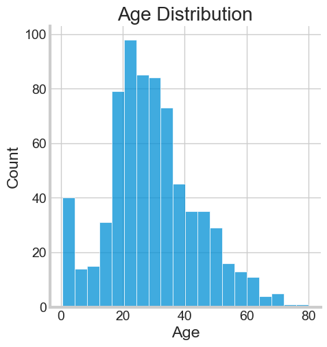

```python
plt.figure(figsize=(4, 3))
sns.displot(df_new['Age'])
plt.title('Age Distribution')
plt.show()
```

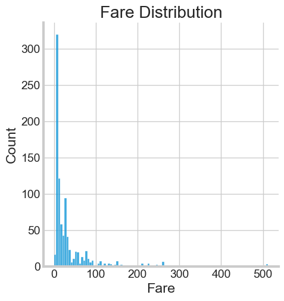

```python
plt.figure(figsize=(4, 3))
sns.displot(df_new['Fare'])
plt.title('Fare Distribution')
plt.show()
```

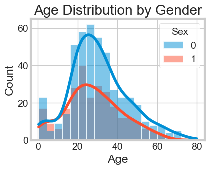

```python
plt.figure(figsize=(4, 3))
sns.histplot(data=df_new, x='Age', kde=True, hue='Sex')
plt.title('Age Distribution by Gender')
plt.show()
```

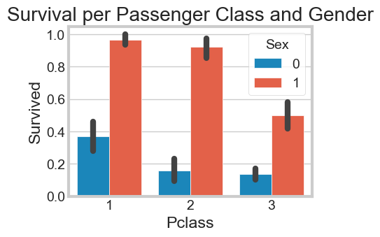

```python
plt.figure(figsize=(4, 3))
sns.barplot(data=df_new, x='Pclass', y='Survived', hue='Sex')
plt.title('Survival per Passenger Class and Gender')
plt.show()
```

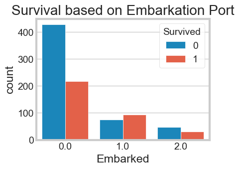

```python
plt.figure(figsize=(4, 3))
sns.countplot(data=df_new, x='Embarked', hue='Survived')
plt.title('Survival based on Embarkation Port')
plt.show()
```

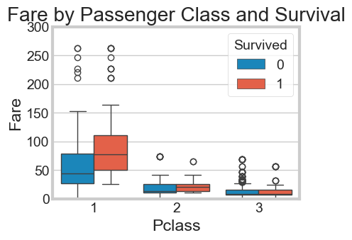

```python
plt.figure(figsize=(4, 3))
sns.boxplot(data=df_new, x='Pclass', y='Fare', hue='Survived')
plt.ylim(0, 300)  # Limiting y-axis to 300 for better visualization
plt.title('Fare by Passenger Class and Survival')
plt.show()
```

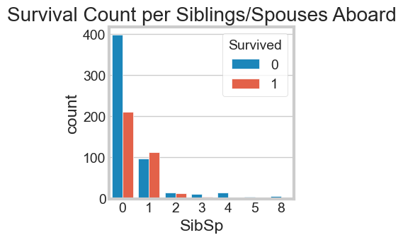

```python
plt.figure(figsize=(3, 3))
sns.countplot(data=df_new, x='SibSp', hue='Survived')
plt.title('Survival Count per Siblings/Spouses Aboard')
plt.show()
```

Data Analysis Findings Based on the analysis we've discussed above, here's a summary of findings for the Titanic incident:

Gender and Survival: Women had a significantly higher survival rate than men.

Passenger Class: First-class passengers had a higher survival rate, indicating socio-economic status played a role in survival chances.

Embarkation Port: The survival count varied based on the embarkation port, potentially reflecting the socio-economic distribution of passengers from these ports.

Fare Distribution: The majority of passengers paid lower fares, aligning with a larger number of third-class tickets.

Siblings/Spouses: Those with one sibling or spouse onboard seemed to have a slightly better survival rate than those alone or with many siblings/spouses.

Age Distribution: Younger passengers (children) had a better survival rate, while the elderly had lower survival chances. Middle-aged individuals, especially males, formed the bulk of casualties.

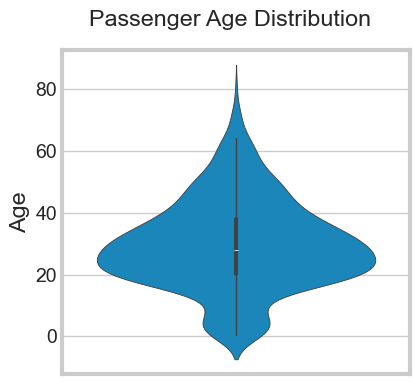

```python
axis = plt.figure(figsize=(4,4))
plt.suptitle('Passenger Age Distribution')
sns.violinplot(df_new['Age'])
```

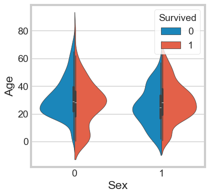

```python
axis = plt.figure(figsize=(4,4))
sns.violinplot(x = 'Sex', y = 'Age', hue = 'Survived', data = df_new, split = True)
```

**Observations:**

This graph showsthe age rangeof men, women and children who were saved. Survival Rate, 1. Good for Children, 2. High for women between the age range 20-50, 3. Less for men with increasing age.

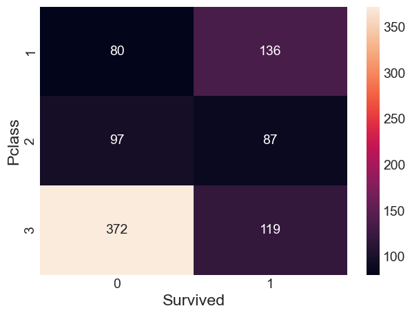

```python
a = df_new.groupby(['Pclass', 'Survived'])
pclass_survived = a.size().unstack()
sns.heatmap(pclass_survived, annot = True, fmt = "d")
```

# Feature Creation & Making Category:

```
       Two features, 'Age' and 'Fare' can be further categorised.
```

**A. Making Category:**

**i. Age:**

```
        We need to make different age-groups based on this feature, while keeping in mind the the new category is well distrubuted
```

```python
var = [df_new]

for data in var:
    dataset['Age'] = dataset['Age'].astype(int)
    data.loc[data['Age'] <= 11, 'Age'] = 0
    data.loc[(data['Age'] > 11) & (data['Age'] <= 18), 'Age'] = 1
    data.loc[(data['Age'] > 18) & (data['Age'] <= 22), 'Age'] = 2
    data.loc[(data['Age'] > 22) & (data['Age'] <= 27), 'Age'] = 3
    data.loc[(data['Age'] > 27) & (data['Age'] <= 33), 'Age'] = 4
    data.loc[(data['Age'] > 33) & (data['Age'] <= 40), 'Age'] = 5
    data.loc[(data['Age'] > 40) & (data['Age'] <= 66), 'Age'] = 6
    data.loc[(data['Age'] > 65)]  = 7

df_new['Age'].value_counts()
```

```
Age
4    162
6    161
3    141
5    139
2    119
1     94
0     68
7      7
Name: count, dtype: int64
```

**ii. Fare:**

```python
df_new.head(10)
```

[output not shown]

```python
var = [df_new]

for data in var:
    data.loc[data['Fare'] <= 7.91, 'Fare'] = 0
    data.loc[(data['Fare'] > 7.91) & (data['Fare'] <= 14.454), 'Fare'] = 1
    data.loc[(data['Fare'] > 14.454) & (data['Fare'] <= 31), 'Fare']   = 2
    data.loc[(data['Fare'] > 31) & (data['Fare'] <= 99), 'Fare']   = 3
    data.loc[(data['Fare'] > 99) & (data['Fare'] <= 250), 'Fare']   = 4
    data.loc[ data['Fare'] > 250, 'Fare'] = 5
    data['Fare'] = data['Fare'].astype(int)
```

**B. Creating New Features:**

**i. Age times Class**

```python
var = [df_new]
for data in var:
    data['Age_Class']= data['Age']* data['Pclass']
```

**2. Fare per Person:**

```python
var = [df_new]

for data in var:
    data['relatives'] = data['SibSp'] + data['Parch']
    data.loc[dataset['relatives'] > 0, 'not_alone'] = 0
    data.loc[dataset['relatives'] == 0, 'not_alone'] = 1
    data['not_alone'] = data['not_alone'].astype(int)
df_new['not_alone'].value_counts()
```

```
not_alone
1    531
0    360
Name: count, dtype: int64
```

```python
var = [df_new]

for data in var:
    data['Fare_Per_Person'] = data['Fare']/(data['relatives']+1)
    data['Fare_Per_Person'] = data['Fare_Per_Person'].astype(int)
```

[output not shown]

```python
df_new.head(5).T
```

[output not shown]